# The impact of screening and travel restrictions on daily exportation risk of 2019-nCoV to directly connected airports

Petra Klepac, Adam Kucharski, CMMID nCoV working group, Mark Jit

## Abstract

We calculate the daily exportation risk from Wuhan Tianhe airport to other directly connected locations based on mean estimated prevalence of 2019-nCoV in Wuhan (Kucharski et al. 2020) and available flight data. We had access to two different sources of flight data: 1) OAG flight data for January 2020 from Wuhan Tianhe airport limited to destinations in Asia and Dubai, and 2) monthly passenger data from 2019 in the month up to the Chinese New Year, from Wuhan Tianhe airport to 20 directly connected cities worldwide. We also consider the impact of screening for symptomatic passengers at origin, and broader flight and travel restrictions.

## Flight data and infection exportations (importations)

OAG Flight data for January 2020 is provided by Department for Transport (Aviation & International Statistics, Aviation & Maritime Analysis) and is treated as sensitive data and therefore cannot be shared. The other flight data set came from HKU presentation [note PK: *not sure if that presenation is in public domain*].

In each flight data set, we have the monthly number of passengers $m_i$ (based on flight seat capacity) from Wuhan Tianhe airport to a given destination $i$. Given the passenger makes the trip, the daily probability that city $i$ is their destination is then $p_i = \dfrac{m_i}{d \sum_i m_i}$, where $d$ is the number of days in a month (or a number of days prior to implementation of travel restrictions). The daily probability that a random inhabitant of Wuhan travels and reaches destination $i$ is $P_i = p_i/N$ where $N$ is the population size of Wuhan (alternatively, $N$ could be the population size of the catchment area of Wuhan Tianhe airport). Assuming random mixing and that healthy and infected individuals are equally likely to travel, the expected number of infected individuals to reach a destination $i$ on day $t$ is $E[I_i(t)] = P_i \hat{I}_{Wuhan}(t)$ where $\hat{I}_{Wuhan}(t)$ is the mean estimated prevalence for Wuhan at time $t$ (Fig1).

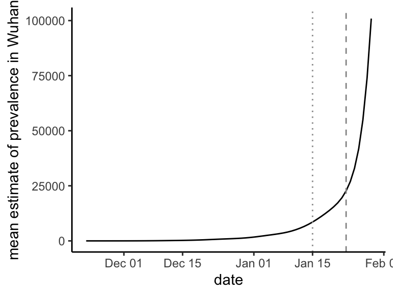

Figure 1. Mean estimated Wuhan prevalence from Kucharski et al. (2020). Dotted line indicates the start of the symptomatic screening of exit passengers on Jan 15 2020 and dashed line indicates the start of flight restrictions on Jan 23.

Using this prevalence, we can calculate the expected number of importations to each location in the absence of any restrictions (Fig2 A) based on the passenger flows. On Jan 15 Wuhan airport implemented exit screening of all passengers based on their symptoms (fever) which we assume to be 50% effective. Travel restrictions were implemented on Jan 23 in Wuhan, affecting all flights, which we assume to be 97% effective as some people might have travelled by other means.

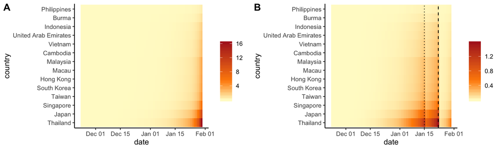

Figure 2. Expected number of importations from Wuhan in the absence (A) and presence (B) of screening and restrictions. Screening efficacy = 50%, travel restriction efficacy = 97%.

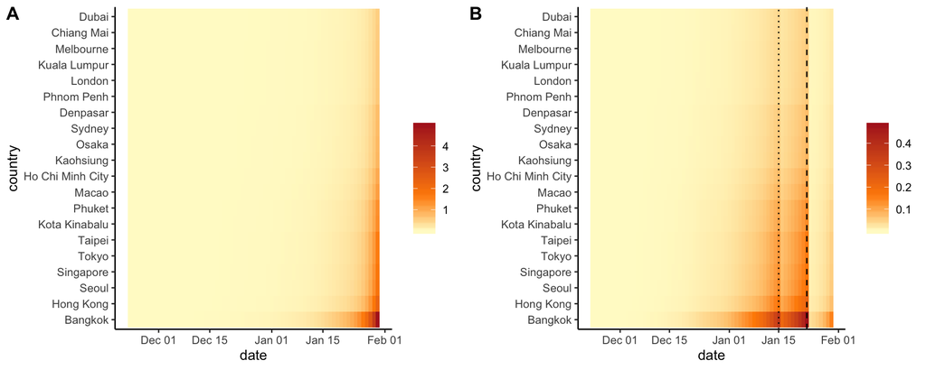

Figure 3. Expected number of importations from Wuhan in absence of restrictions (A) and the presence of screening and restrictions (B). Screening efficacy = 50%, travel restriction efficacy = 97%.

## Probability of infection establishing in a new location

Whether or not $E[I_i]$ successfully seed the local outbreak depend on several factors, such as frequency of travel, duration of visit, local population size, and local mixing of the population (so factors to do with movement), as well as local control strategies. In the absence of control, the probability that importations lead to an outbreak is proportional to $1-1/R_0$ (assuming Poisson distributed secondary infections, from branch theory). Following Klepac, Kissler, and Gog (2018), the force of infection $\lambda_i$ from Wuhan in a location $i$ where infection is not yet established is then
$$\lambda_i (t) \sim \xi \left(1-\dfrac{1}{R_0} \right) E[I_i(t)]$$
. Note that as infection spreads and gets established in more countries, $\lambda_i$ would have to sum over all infected locations to find the local force of infection due to importations. The probability of infection establishing in location $i$ at time $t$ would then be
$$\mathbb{P}(\tau_i = t) = 1 - e^{-\lambda_i(t)}$$

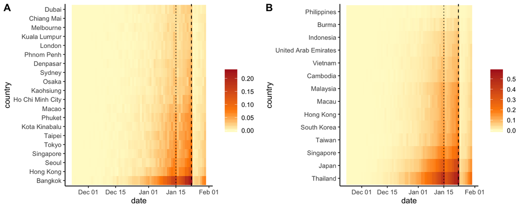

Figure 4. Risk of seeding a local outbreak for the two sets of flight data. Screening efficacy = 50%, travel restriction efficacy = 97%.

## International importations data

Finally, we compare the expected number of daily exportations from Wuhan with the observed international cases from WHO situation reports (WHO 2020).

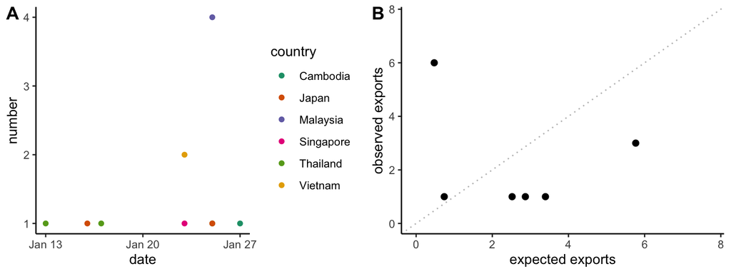

Figure 5. A) international cases exported from Wuhan by date, B) expected and observed number of total daily exportations.

## References

Klepac, Petra, Stephen Kissler, and Julia Gog. 2018. “Contagion! The BBC Four Pandemic – The model behind the documentary.” *Epidemics* 24 (September). Elsevier: 49–59. https://doi.org/10.1016/j.epidem.2018.03.003.

Kucharski, Adam J, Timothy W Russell, Charlie Diamond, CMMID nCoV working Group, Sebastian Funk, and Rosalind M Eggo. 2020. “Early dynamics of transmission and control of 2019-nCoV: a mathematical modelling study.” *medRxiv*, February. Cold Spring Harbor Laboratory Press, 2020.01.31.20019901. https://doi.org/10.1101/2020.01.31.20019901.

WHO. 2020. “Novel Coronavirus ( 2019-nCoV ), Situation Report-1, 21 January 2020.” January. https://www.who.int/docs/default-source/coronaviruse/situation-reports/20200126-sitrep-6-2019--ncov.pdf.